# EMPRÉSTIMOS FINANCIADOS PELA PROSPER

Nos gráficos abaixo podemos analisar o comportamento tanto da média da taxa de juros quanto a média do valor emprestado por faixa de renda. Talve até identificar pontos de um que reflete no outro. Segue:

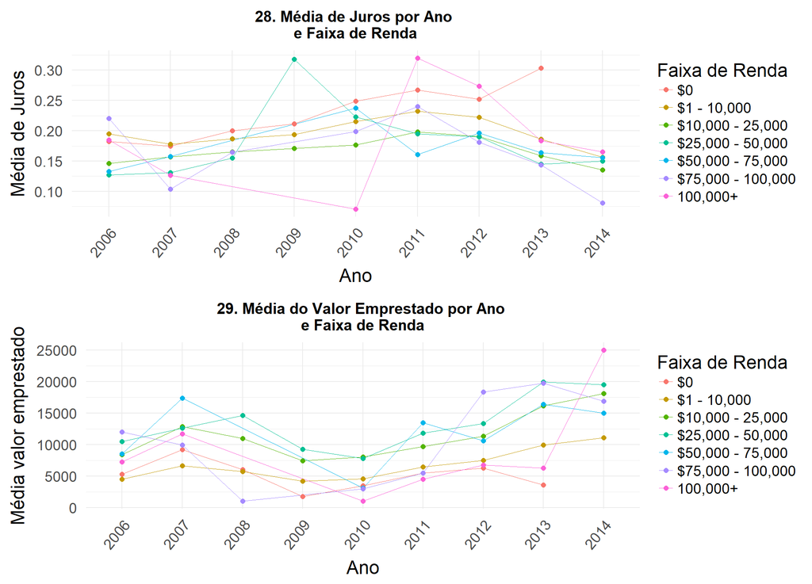

Para analisar os gráficos acima, é necessário investigar caso a caso. Vamos ver algumas descobertas:

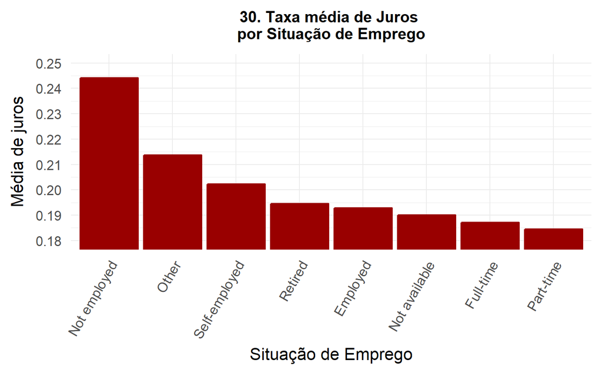

Respondendo a pergunta 5 sim, mutuários que estão desempregados tem uma taxa de juros bem maior do que os que estão empregados.

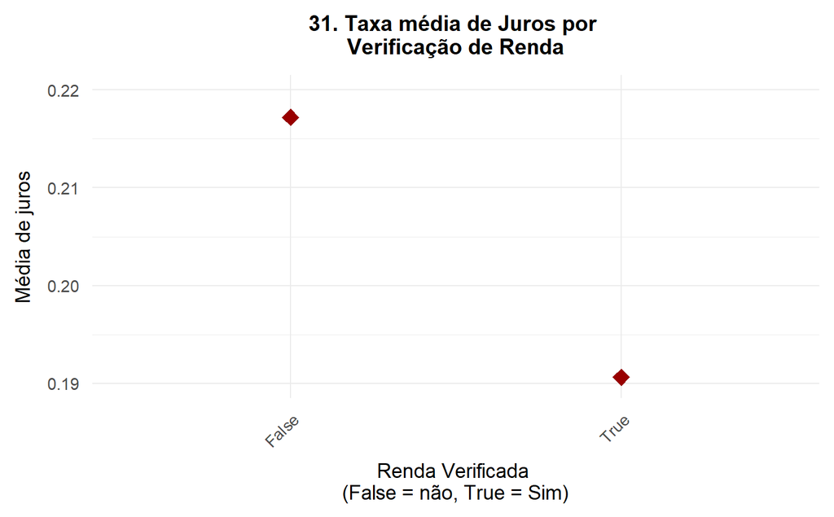

A resposta para a pergunta 6 também é afirmativa, mutuários que estão empregados e comprovam sua renda tem juros menores do que as que não comprovam a renda. Vale ressaltar que os mutuários que não comprovaram renda ainda tem uma taxa de juros média menor do que quem tem a situação de emprego como “Não Empregado” (Not employed).

# E. CORRELAÇÕES

| Range coeficiente | Força da correlação |
| --- | --- |
| 0,2 < r < 0,4 | Correlação fraca |
| 0,4 < r < 0,7 | Correlação moderada |
| 0,7 < r < 0,9 | Correlação forte |

*Onde r = coeficiente de correlação linear*

Vamos calcular o coeficiente de correlação usando o método de Pearson para encontrar a correlação entre o PropScore e a Taxa de Juros:

> Para análise do PropScore, iremos considerar somente as observações onde esta variável é diferente de nulo.

```
##
##  Pearson's product-moment correlation
##
## data:  df_score$ProsperScore and df_score$BorrowerRate
## t = -248.98, df = 84851, p-value < 2.2e-16
## alternative hypothesis: true correlation is not equal to 0
## 95 percent confidence interval:
##  -0.6536072 -0.6458311
## sample estimates:
##        cor
## -0.6497361
```

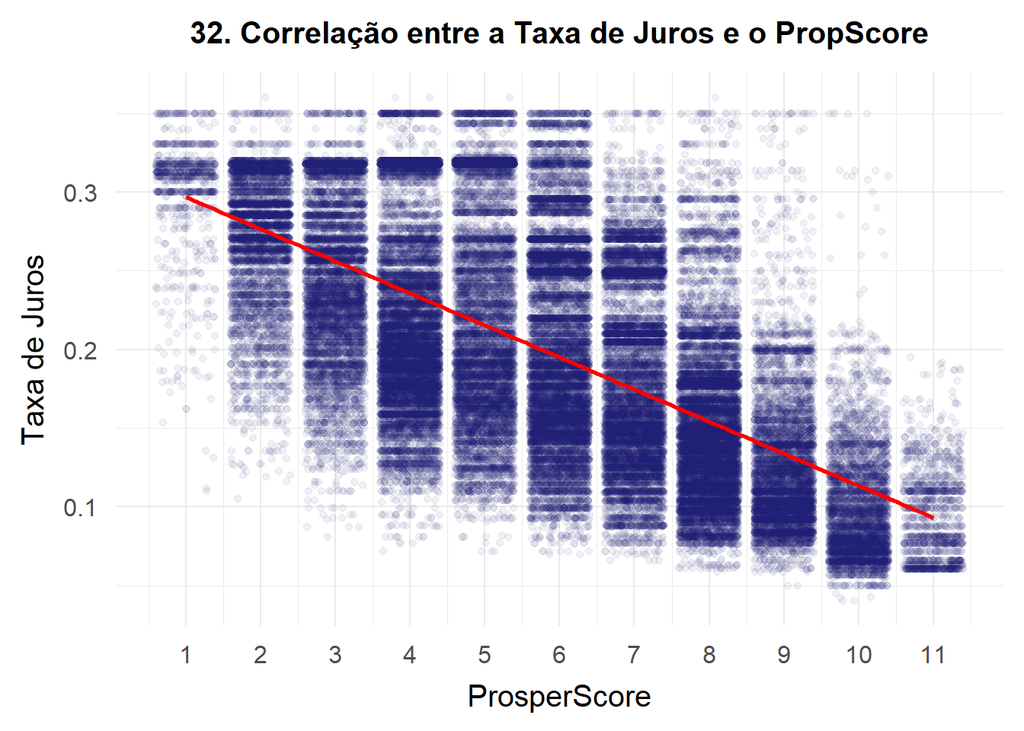

Existem outras variáveis que provavelmente tem uma correlação entre si. Ao invés de realizarmos suposições, vamos gerar uma matriz de correlação para facilitar nossa Análise.

**33. MATRIZ DE CORRELAÇÃO**

Vamos agora selecionar somente alguns campos da nossa base:

> Obs.: Para possibiitar a geração da matriz de correlação é utilizada uma amostra da nossa base de dados. Significa que pode gerar pequenas diferenças de resultados se comparado com o cálculo da base toda.

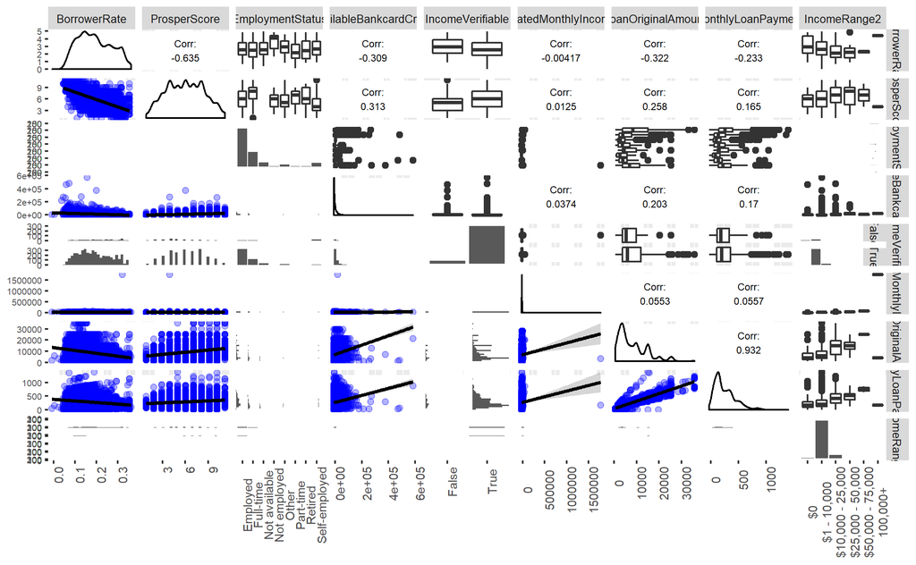

Algumas correlações identificadas são óbvias, e por isso não poderemos considerá-las, como por exemplo o valor mensal a ser pago com o valor total emprestado. Esta relação quase sempre estará relacinonada. Neste caso, o coeficiente de correlação foi bastante alto: 0,93.

Vamos analisar a correlação entre o Propscore e o Valor emprestado.

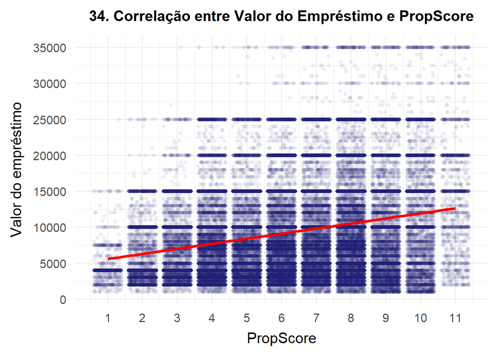

Apesar de haver uma tendência como pode-se ver os valores mais altos a partir do PropScore 7, a correlação identifica é considerada fraca.

Será que quanto maior o valor, menor é a taxa de juros?

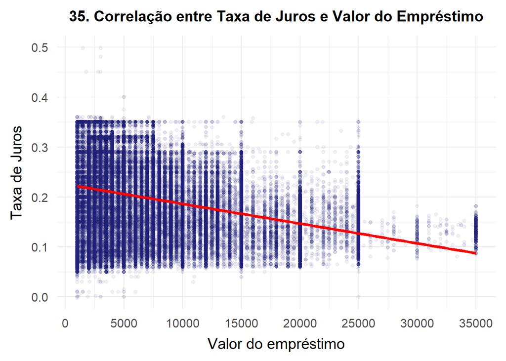

Também é uma correlação fraca.

Devido à grande diferença entre os valores disponíveis, tive que usar a função sqrt para calcularmos a raiz quadrada do valor disponível do cartão de credito e assim visualizarmos o gráfico com maior facilidade:

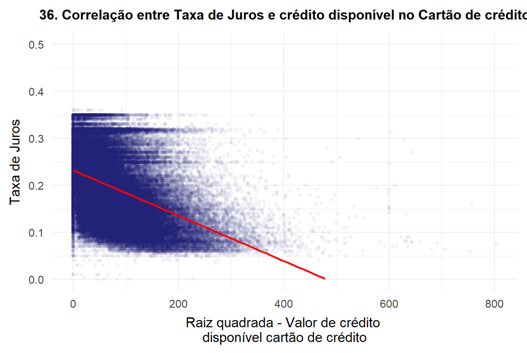

# F. GRÁFICOS FINAIS E RESUMO

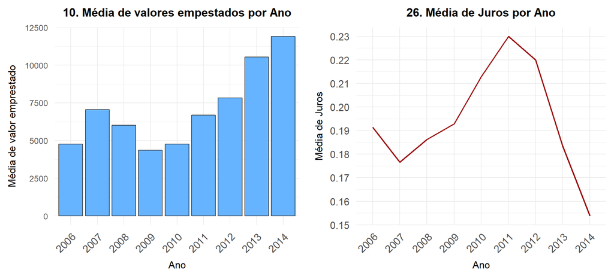

As análises mostram uma tendência que indica que em 2014 será o ano com maior valor de empréstimo de todos os anos. O gráfico de média de juros, indica uma queda acentuada da taxa de juros a partir do ano de 2012. O ano de 2014 até agora é o ano com menor taxa de juros.

Sabe-se que a taxa de juros está intimamente ligada ao risco. Quanto maior o risco do investidor em não receber o pagamento pelo empréstimo, maior será a taxa de juros.

Os gráficos abaixo indicam fatores que podem apresentar risco:

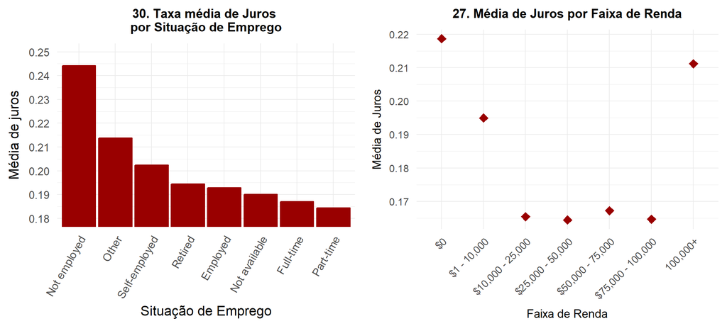

Segue abaixo algumas descobertas do estudo:

- Quem esta desempregado, tem a taxa de juros muito maior do que quem está empregado.
- Vale ressaltar que dos mutuários que estão empregados, os que comprovaram sua renda tem juros muito menores do que os que não comprovaram.
- Em geral, quem tem maior renda paga menos juros para o empréstimo (Com exceção de quem ganha acima de US$ 100.000. Para estes casos, uma hipótese que poderia justificar o alto percentual de juros talvez possa ser a de que o mutuário não administra bem os seus recursos).

# G. REFLEXÃO

Esse estudo foi realizado analisando uma série de informações da base de dados, procurando conhecer as informações e uma maneira geral e direcionando o estudo para responder perguntas sobre a taxa de juros aplicada nos diferentes empréstimos.

Apesar de termos analisado uma série de variáveis, pode-se dizer que para o cálculo da taxa de juros é considerado não só um fator, e sim uma série de fatores. Alguns influenciam mais, outros nem tanto. O PropScore é o índice que mais teve influência com no percentual de juros utilizado no empréstimo. Ele provavelmente é calculado considerando uma série de características, como por exemplo o fato da pessoa estar trabalhando ou não, sua faixa de renda, se a renda foi ou não foi comprovada, etc. Outro fator importante é a quantidade de parcelas para pagamento do empréstimo. Em 12 vezes, o juros aplicado é bem menor do que parcelamentos em 36 e 60 meses.

Esta é uma base de dados bastante rica, e que possibilita uma série de insights. A maior dificuldade na realização deste estudo foi em meio a 81 variáveis identificar as com maior relevância. Apesar de haver um dicionário de dados, a forma exata de como cada variável funciona muitas vezes não está clara. A criação do mapa mental ajudou bastante nesse processo de eliminação de variáveis que não faziam tanto sentido, me ajudou a focar no objetivo e a identificar mais questões a serem respondidas. A partir daí, pouco a pouco fui me familiarizando com os comandos do R e a medida que eu fui avançando, mais insights foram acontecendo.

Um próximo passo para esse estudo seria analisar as características dos empréstimos que estão inadimplentes. Identificar os diferentes padrões destes com relação aos empréstimos com pagamento em dia. Para realizar esta identificação, poderia também serem utilizadas técnicas de machine learning, como por exemplo classificação ou clusterização. Uma outra sugestão seria analisar as demais variáveis da base de dados disponíveis na base de dados juntamente com informações mais atualizadas, contendo dados de anos mais atuais (considerando que o ultimo ano que temos é o de 2014).

Apesar do propósito deste projeto ter sido cumprido, tenho certeza que com mais tempo e mais prática, poderia criar gráficos mais sofisticados, realizando a junção de visões facilitando ainda mais a compreensão e prosseguindo com a identificação de novas descobertas.

Até o próximo projeto!

# H. REFERÊNCIAS

- Prosper
- https://www.prosper.com/
- https://en.wikipedia.org/wiki/Prosper_Marketplace
- Otimização do tamanho das imagens
- http://optipng.sourceforge.net/
- https://www.zevross.com/blog/2017/06/19/tips-and-tricks-for-working-with-images-and-figures-in-r-markdown-documents/
- https://www.linuxhelp.com/install-jpegoptim-optipng-linux/
- Coeficiente de correlação
- http://w3.ufsm.br/adriano/aulas/coreg/Aula%2001%20Correla%E7ao%20Linear.pdf
- Formatação R Markdown
- https://www.rstudio.com/wp-content/uploads/2015/02/rmarkdown-cheatsheet.pdf
- Visualização
- http://r-statistics.co/Top50-Ggplot2-Visualizations-MasterList-R-Code.html
- https://stackoverflow.com/questions/39709745/decreasing-the-line-thickness-and-corr-font-size-in-ggpairs-plot
- https://github.com/ggobi/ggally/issues/6